# Lab03

Hadrizia Santos

26 de fevereiro de 2018

**Carregando bibliotecas necessárias**

*Carregando, separando em treino e teste e pre processando os dados*

```r
## carregando os dados de treino
input <- read.csv("~/Downloads/LabsAD2/Lab03/train.csv", encoding = "latin1")

## pre-processando os dados (removendo variáveis irrelevantes)
input <- input %>% select(-ID, -nome, -numero_cadidato, -idade, -estado_civil, -grau, -setor_economico_despesa, -setor_economico_receita)

# carregando os dados de teste
input_teste <- read.csv("~/Downloads/LabsAD2/Lab03/test.csv", encoding = "latin1")

# para uso da submissao no Kaggle
ID <-input_teste %>% select(ID)
input_teste <- input_teste %>% select(-ID, -nome, -numero_cadidato, -idade, -estado_civil, -grau,
                                      -setor_economico_despesa, -setor_economico_receita)

## criando partição de 75% em treino e 25% em teste
dataPartition <- createDataPartition(y = input$situacao_final, p=0.75, list=FALSE)

## Setando a seed para fazer a partição reproduzível
set.seed(9560)

## separando o dataframe em treino e teste
train_data <- input[dataPartition, ]
test_data <- input[-dataPartition, ]
```

**1. Há desbalanceamento das classes (isto é, uma classe tem muito mais instâncias que outra)? Em que proporção? Quais efeitos colaterais o desbalanceamento de classes pode causar no classificador?**

Para responder a esta pergunta, precisamos contabilizar as instâncias das classes de situacao_final para verificar se há desbalanceamento entre elas.

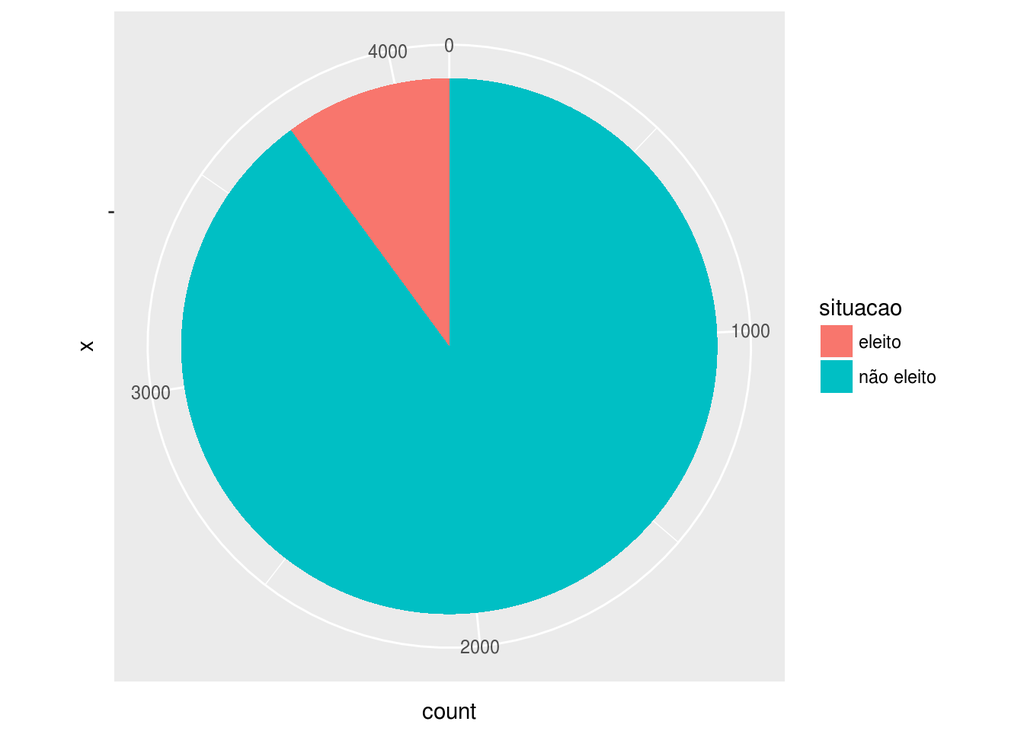

```r
cont_nao_eleito <- input %>% select(situacao_final) %>% filter(situacao_final == 'nao_eleito') %>% nrow()
cont_eleito <- input %>% select(situacao_final) %>% filter(situacao_final == 'eleito') %>% nrow()

df = data.frame(situacao = c("eleito", "não eleito"), count = c(cont_eleito, cont_nao_eleito))

ggplot(df, aes(x="", y=count, fill=situacao))+
geom_bar(width = 1, stat = "identity") +
   coord_polar("y", start=0)
```

Como se pode observar no gráfico acima, há um grande desbalanceamento das classes de situacao_final. o número de candidatos não eleitos é quase 10 vezes maior do que o número de candidatos eleitos. Este é um problema que possui como principal efeito colateral a redução da acurácia dos modelos, uma vez que o classificador vai tender para a classe majoritária (neste casso, a não eleição dos votos).

Para contornar o problema do desbalanceamento existem algumas formas, destacando-se undersampling, que consiste em remover algumas instâncias do dataset cuja classe é a majoritária e oversampling, que cria instâncias da classe minoritária.

Abaixo tem-se os dois métodos citados acima, além do método ROSE, e lista o número de instâncias de cada método utilizado.

```r
train_data <- train_data %>% select(-recursos_de_outros_candidatos.comites, -recursos_de_partidos, -recursos_de_pessoas_fÃ.sicas, -recursos_de_pessoas_juridicas, -recursos_proprios)

#input_teste$isDeputado <- ifelse(input_teste$descricao_ocupacao == "DEPUTADO", 1, 0)
#input_teste <- input_teste %>% select(total_receita, despesa_max_campanha, isDeputado)

rose_train <- ROSE(situacao_final ~ ., data  = train_data)$data
table(rose_train$situacao_final)
```

```
##
## nao_eleito     eleito
##       1520       1582
```

```r
up_train <- upSample(x = train_data[,],
                     y = train_data$situacao_final)

up_train <- up_train %>% select(-Class)
table(up_train$situacao_final)
```

```
##
##     eleito nao_eleito
##       2790       2790
```

```r
down_train <- downSample(x = train_data[, -ncol(train_data)],
                         y = train_data$situacao_final)
down_train <- down_train %>% select(-Class)
table(down_train$situacao_final)
```

```
## < table of extent 0 >
```

O método escolhido será o ROSE, que tanto cria instâncias da classe minoritária quanto diminui instâncias da classe majoritária.

**2. Treine: um modelo de regressão logística, uma árvore de decisão e um modelo de adaboost. Tune esses modelos usando validação cruzada e controle overfitting se necessário, considerando as particularidades de cada modelo.**

```r
# usando validação cruzada 10-fold com 5 repetições
fitControl <- trainControl(method = "repeatedcv",
                           number = 10,
                           repeats = 5,
                           classProbs = TRUE)
```

Regressão Logística

```r
reg_logistica <- glm(formula=situacao_final~., data = rose_train, family=binomial)
```

Árvore de decisão

```r
arvore <- train(
    x = rose_train[, names(rose_train) != "situacao_final"],
    y = rose_train$situacao_final,
    method = "rpart",
    trControl = fitControl,
    control = rpart.control(cp = 0.4))
```

Adaboost

```r
adaboost <- train(x = rose_train[, names(rose_train) != "situacao_final"],
                y = rose_train$situacao_final,
                method = "adaboost",
                trControl = fitControl)
```

**3. Reporte acurácia, precision, recall e f-measure no treino e validação. Como você avalia os resultados? Justifique sua resposta.**

A análise será feita no modelo adaboost.

```r
# realizando predição
test_data$prediction <- predict(adaboost, test_data)

# para uso da submissao no Kaggle
#newCSV <- ID
#newCSV$prediction <- prediction
#write.csv(newCSV, "sample_submission.csv", row.names=FALSE)

# vezes que o modelo acertou na predição de que o candidato seria eleito
TP <- test_data %>% filter(situacao_final == "eleito", prediction == "eleito") %>% nrow()

# vezes que o modelo acertou na predição de que o candidato seria nao_eleito
TN <- test_data %>% filter(situacao_final == "nao_eleito" , prediction == "nao_eleito" ) %>% nrow()

# vezes que o modelo errou na predição de que o candidato seria nao_eleito
FP <- test_data %>% filter(situacao_final == "nao_eleito" , prediction == "eleito") %>% nrow()

# vezes que o modelo errou na predição de que o candidato seria eleito
FN <- test_data %>% filter(situacao_final == "eleito", prediction == "nao_eleito" ) %>% nrow()

# proporção de observações corretamente classificadas
accuracy <- (TP + TN)/(TP + TN + FP + FN)

# quantas das observaçoes preditas como positivas são realmente positivas
precision <- TP / (TP + FP)

# quantas das observaçoes positivas foram corretamente classificadas
recall <- TP / (TP + FN)

# média harmônica da precisão e recall
f_measure <- 2 * (precision * recall) / (precision + recall)

f_measure
```

```
## [1] 0.718894
```

```r
accuracy
```

```
## [1] 0.9409487
```

```r
precision
```

```
## [1] 0.6902655
```

```r
recall
```

```
## [1] 0.75
```

```r
confusionMatrix(test_data$prediction, test_data$situacao_final)
```

```
## Confusion Matrix and Statistics
##
##             Reference
## Prediction   eleito nao_eleito
##   eleito         78         35
##   nao_eleito     26        894
##
##                Accuracy : 0.9409
##                  95% CI : (0.9248, 0.9545)
##     No Information Rate : 0.8993
##     P-Value [Acc > NIR] : 1.259e-06
##
##                   Kappa : 0.686
##  Mcnemar's Test P-Value : 0.3057
##
##             Sensitivity : 0.75000
##             Specificity : 0.96233
##          Pos Pred Value : 0.69027
##          Neg Pred Value : 0.97174
##              Prevalence : 0.10068
##          Detection Rate : 0.07551
##    Detection Prevalence : 0.10939
##       Balanced Accuracy : 0.85616
##
##        'Positive' Class : eleito
##
```

```r
varImp(adaboost)
```

```
## ROC curve variable importance
##
##                         Importance
## total_receita               100.00
## total_despesa                97.66
## quantidade_doacoes           75.59
## media_receita                73.06
## quantidade_despesas          70.54
## media_despesa                67.03
## quantidade_doadores          63.69
## quantidade_fornecedores      50.08
## descricao_ocupacao           39.98
## sexo                         19.64
## descricao_cor_raca           17.61
## despesa_max_campanha         13.48
## UF                            9.30
## partido                       0.00
```

**4. Interprete as saídas dos modelos. Quais atributos parecem ser mais importantes de acordo com cada modelo? Crie pelo menos um novo atributo que não está nos dados originais e estude o impacto desse atributo.**

Vamos analisar o impacto, em cada modelo, de criar um novo atributo chamado isDeputado, que possui valor 1 caso o candidato já seja deputado e 0, caso contrário.

```r
rose_train$isDeputado <- ifelse(rose_train$descricao_ocupacao == "DEPUTADO", 1, 0)
test_data$isDeputado <- ifelse(test_data$descricao_ocupacao == "DEPUTADO", 1, 0)
```

Regressão Logística

```r
# antes do atributo
summary(reg_logistica)
```

```
##
## Call:
## glm(formula = situacao_final ~ ., family = binomial, data = rose_train)
##
## Deviance Residuals:
##     Min       1Q   Median       3Q      Max
## -3.6060  -0.2390   0.0012   0.2586   2.6717
##
## Coefficients:
##                                                                                                                          Estimate
## (Intercept)                                                                                                            -2.012e+01
## UFAL                                                                                                                   -5.284e-01
## UFAM                                                                                                                   -1.059e+00
## UFAP                                                                                                                    8.227e-01
## UFBA                                                                                                                   -5.758e-01
## UFCE                                                                                                                    5.414e-01
## UFDF                                                                                                                   -1.865e+00
## UFES                                                                                                                   -1.237e+00
## UFGO                                                                                                                   -1.827e+00
## UFMA                                                                                                                    6.417e-01
## UFMG                                                                                                                   -1.343e+00
## UFMS                                                                                                                   -2.497e+00
## UFMT                                                                                                                   -6.733e-01
## UFPA                                                                                                                   -1.009e-01
## UFPB                                                                                                                    1.228e-01
## UFPE                                                                                                                    1.078e+00
## UFPI                                                                                                                   -1.038e+00
## UFPR                                                                                                                   -2.281e-01
## UFRJ                                                                                                                   -3.025e-02
## UFRN                                                                                                                    1.716e+00
## UFRO                                                                                                                   -1.858e-01
## UFRR                                                                                                                   -2.297e-01
## UFRS                                                                                                                    6.205e-02
## UFSC                                                                                                                    8.387e-01
## UFSE                                                                                                                   -2.821e-01
## UFSP                                                                                                                   -1.160e+00
## UFTO                                                                                                                   -2.955e-01
## partidoPCB                                                                                                             -1.810e+01
## partidoPC do B                                                                                                          4.961e-01
## partidoPCO                                                                                                              1.774e+00
```

[output cut: 929 more lines]

```
## descricao_cor_racaBRANCA
## descricao_cor_racaINDÃ\u008dGENA
## descricao_cor_racaPARDA
## descricao_cor_racaPRETA
## despesa_max_campanha
## ---
## Signif. codes:  0 '***' 0.001 '**' 0.01 '*' 0.05 '.' 0.1 ' ' 1
##
## (Dispersion parameter for binomial family taken to be 1)
##
##     Null deviance: 4299.0  on 3101  degrees of freedom
## Residual deviance: 1375.9  on 2910  degrees of freedom
## AIC: 1759.9
##
## Number of Fisher Scoring iterations: 18
```

```r
# re-treinando o modelo
reg_logistica <- glm(formula=situacao_final~., data = rose_train, family=binomial)
```

```r
# depois do atributo
summary(reg_logistica)
```

```
##
## Call:
## glm(formula = situacao_final ~ ., family = binomial, data = rose_train)
##
## Deviance Residuals:
##     Min       1Q   Median       3Q      Max
## -3.6060  -0.2390   0.0012   0.2586   2.6717
##
## Coefficients: (1 not defined because of singularities)
##                                                                                                                          Estimate
## (Intercept)                                                                                                            -2.012e+01
## UFAL                                                                                                                   -5.284e-01
## UFAM                                                                                                                   -1.059e+00
## UFAP                                                                                                                    8.227e-01
## UFBA                                                                                                                   -5.758e-01
## UFCE                                                                                                                    5.414e-01
## UFDF                                                                                                                   -1.865e+00
## UFES                                                                                                                   -1.237e+00
## UFGO                                                                                                                   -1.827e+00
## UFMA                                                                                                                    6.417e-01
## UFMG                                                                                                                   -1.343e+00
## UFMS                                                                                                                   -2.497e+00
## UFMT                                                                                                                   -6.733e-01
## UFPA                                                                                                                   -1.009e-01
## UFPB                                                                                                                    1.228e-01
## UFPE                                                                                                                    1.078e+00
## UFPI                                                                                                                   -1.038e+00
## UFPR                                                                                                                   -2.281e-01
## UFRJ                                                                                                                   -3.025e-02
## UFRN                                                                                                                    1.716e+00
## UFRO                                                                                                                   -1.858e-01
## UFRR                                                                                                                   -2.297e-01
## UFRS                                                                                                                    6.205e-02
## UFSC                                                                                                                    8.387e-01
## UFSE                                                                                                                   -2.821e-01
## UFSP                                                                                                                   -1.160e+00
## UFTO                                                                                                                   -2.955e-01
## partidoPCB                                                                                                             -1.810e+01
## partidoPC do B                                                                                                          4.961e-01
## partidoPCO                                                                                                              1.774e+00
```

[output cut: 934 more lines]

```
## descricao_cor_racaINDÃ\u008dGENA
## descricao_cor_racaPARDA
## descricao_cor_racaPRETA
## despesa_max_campanha
## isDeputado
## ---
## Signif. codes:  0 '***' 0.001 '**' 0.01 '*' 0.05 '.' 0.1 ' ' 1
##
## (Dispersion parameter for binomial family taken to be 1)
##
##     Null deviance: 4299.0  on 3101  degrees of freedom
## Residual deviance: 1375.9  on 2910  degrees of freedom
## AIC: 1759.9
##
## Number of Fisher Scoring iterations: 18
```